# Incarceration Report

## Introduction

Incarceration is one of the most concerned problems in the United States in many years. Specifically, people of color has been treated with *overpolicing* and *disproportionate* in incarceration. The data about incarceration has been compiled by Vera Institute in a long time about the incarceration in different race. Based on the dataset, this report focuses mainly on black jail population in all counties over time because black people have been victims in this problem. There are 5 relevant values for this variable. For instance, the most recent average of black jail population accross all the counties is 83.5742573. Additionally, the highest black jail population is found in CA, Los Angeles County in 1993. Moreover, an example of total black jail population in a state - Washington - is also calculated which is 1992.39. Besides, top 5 of the counties which have highest black jail population are also measured and used in the **trends over time chart** below.

## Trends over time chart

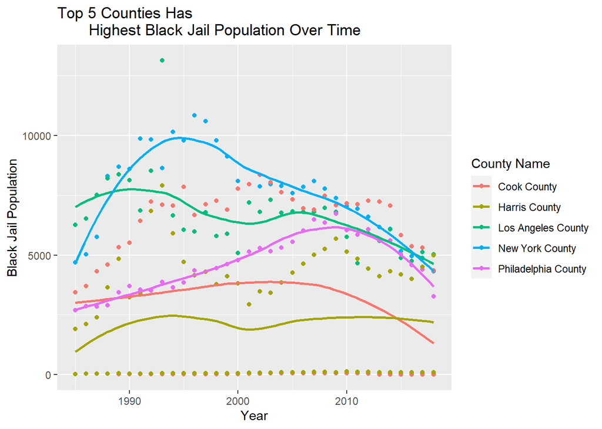

## Variable Comparison Chart

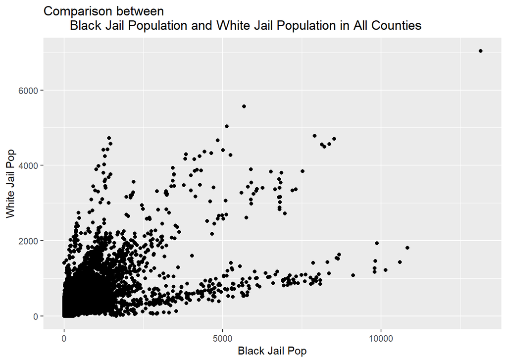

## Map

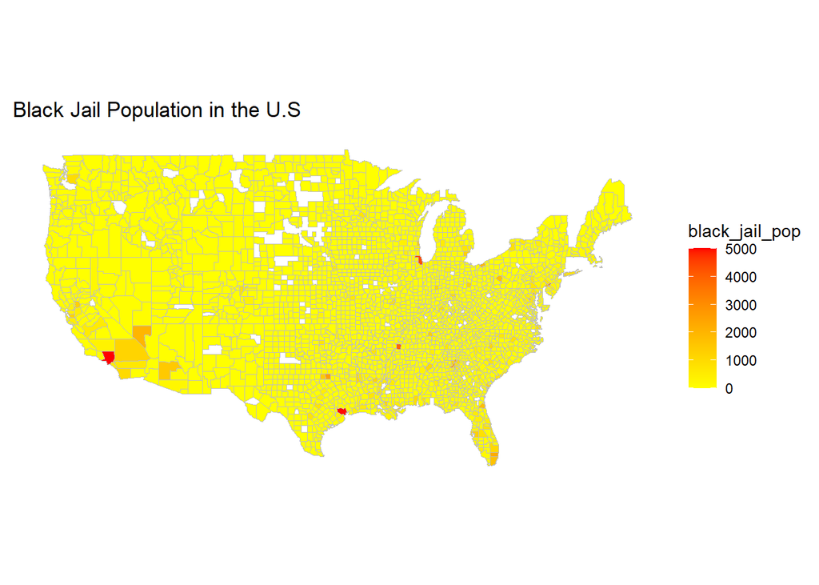

This map is used to show how the black jail population different in different locations. Specifically, this map helps the reader easily to know where the highest or lowest black jail population located, and the gradient of color shows how much different in the black jail population in a county compared to the others. Furthermore, the places with the red color - highest black jail population - is mostly found in the big county with high population. For example, Los Angeles is shown as a highest black jail population with the red color.